# Item Response Theory (IRT)

October 23, 2018

## Classical Test Theory

\[ X_i=T+E_i \]

Test items are scored such that \(X\in{0,1}\), but CTT uses statistics for continuous variables. This works fine for average scores on long tests because the law of large numbers leads error to be normally distributed, but it breaks down somewhat for short tests or when trying to understand the score on an item. i.e. \(E_i=X_i-T=\{0,1\}-T\nsim N(0,\delta_E)\). Classical Test Theory, then, is not ideal for looking item specific characteristics.

## Item Response Theory from CTT

\[ Y_i=T+E_i \]

\[ \begin{align} logit(p_i)=&-1.7*a_i(\theta-b_i)\\ =&-1.7*a_i*\theta+-1.7*a_i*b_i \end{align} \]

We move from modeling the observed scores to modeling the probability of a correct answer. The logit transformation scales the \([0,1]\) probability to a \([-\infty,\infty]\) scale, which allows the use of continuous variables \(\theta\), \(a_i\), and \(b_i\). \(-1.7*a_i\) is akin to a factor loading. The mean is akin to \(-1.7*a_i*b_i\). Error gets absorved into the logit scale.

## Dichotomous Outcome Models for IRT

4PL model:

\[ p_i=c_i+\frac{d_i-c_i}{1+e^{-a_i(\theta-b_i)} } \]

where \(b_i\) is item difficulty, \(a_i\) is item discrimination, \(c_i\) is a guessing parameter, \(d_i\) allows person to miss item they should definitely get.

## Dichotomous Outcome Models

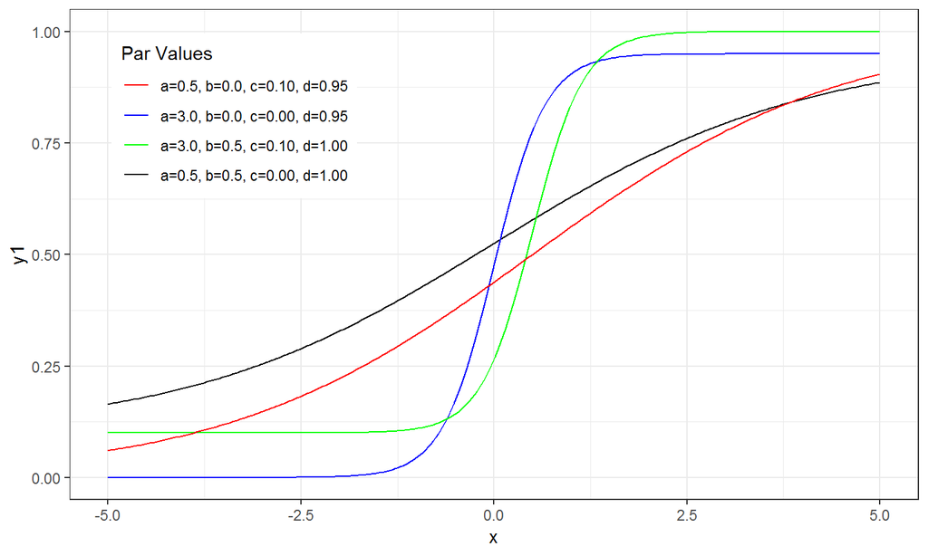

## Graded Response Model

\[ \begin{align} Pr(x_{im}\leq k|\theta)&=\frac{1}{1+e^{-a_i(\theta-b_{ik})} }\\ Pr(x_{im}=k|\theta) &=logistic(\eta_{ik})-logistic(\eta_{i,k+1}) \end{align} \]

where \(k \in \{1,...K\}\) with \(K\) is the number of categories of response.

## Log Items

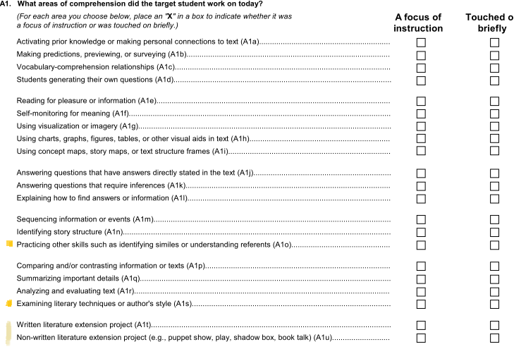

## Assumptions: Local Independence

\[ logit(p_i)=-1.7*a_i(\theta-b_i) \]

Conditional on \(\theta\), the \(p_i\) are independent across \(i\). i.e. "ability" is the only person characteristic affecting scoring items completely.

## Assumptions: Unidimensionality

\[ logit(p_i)=-1.7*a_i(\theta-b_i) \]

\(\theta\) is a single-dimensional characteristic. Some IRT models, called item factor analysis, allow multi-dimensional \(\theta\) variables.

## Dimensionality

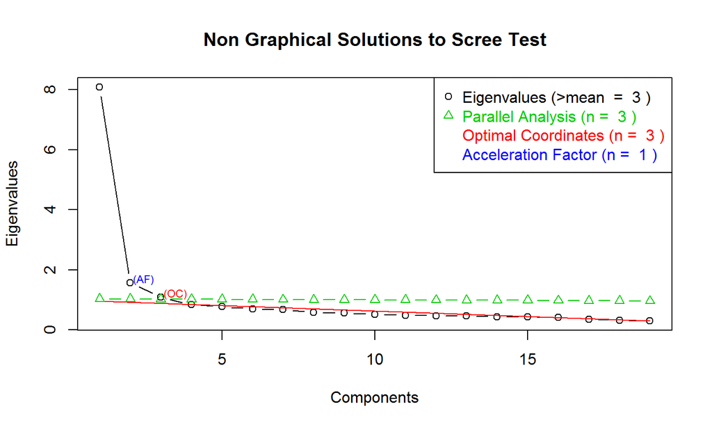

## Dimensionality

```
##
## Loadings:
##       MR1    MR2    MR3
## lla1a         0.722
## lla1b         0.713
## lla1c         0.419
## lla1d  0.564
## lla1e  0.311
## lla1f  0.410
## lla1g  0.621
## lla1h  0.762
## lla1i  0.749
## lla1j                0.726
## lla1k                0.687
## lla1l  0.418         0.332
## lla1m  0.555
## lla1n  0.718
## lla1o  0.826
## lla1p  0.697
## lla1q  0.390
## lla1r  0.746
## lla1t  0.787
##
##                  MR1   MR2   MR3
## SS loadings    5.630 1.437 1.243
## Proportion Var 0.296 0.076 0.065
## Cumulative Var 0.296 0.372 0.437
```

## Remove A,B,C,J,K,L

```r
LALogs <- LALogs %>% select(-lla1a,-lla1b,-lla1c,
                            -lla1j,-lla1k,-lla1l)
```

## Polytomous Model

Does the constrained (i.e. 1PL equivalent) model fit data as well as unconstrained model?

```r
#
graded <- LALogs %>% select(starts_with("lla1")) %>% grm
graded2 <- LALogs %>% select(starts_with("lla1")) %>% grm(constrained=T)
anova(graded2,graded)
```

```
##
##  Likelihood Ratio Table
##            AIC    BIC log.Lik    LRT df p.value
## graded2 871338 871572 -435642
## graded  866147 866485 -433034 5215.6 12  <0.001
```

## Polytomous Model

| Var | beta.1 | beta.2 | beta |
| --- | --- | --- | --- |
| lla1d | 0.75 | 1.98 | 1.44 |
| lla1e | -0.63 | 1.86 | 0.85 |
| lla1f | 0.14 | 1.97 | 1.16 |
| lla1g | 1.00 | 2.55 | 1.67 |
| lla1h | 1.23 | 2.76 | 1.78 |
| lla1i | 0.97 | 2.74 | 1.69 |
| lla1m | 0.34 | 2.12 | 1.31 |
| lla1n | 0.97 | 2.65 | 1.72 |
| lla1o | 1.39 | 2.35 | 2.05 |
| lla1p | 1.15 | 2.59 | 1.65 |
| lla1q | -0.27 | 2.11 | 1.06 |
| lla1r | 1.14 | 2.86 | 1.70 |
| lla1t | 1.38 | 2.63 | 1.56 |

## Item Characteristics Curves

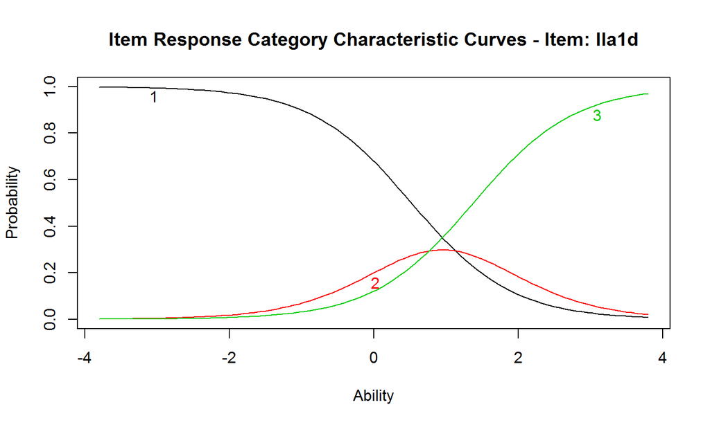

## Score from IRT model

```r
tmp <- ltm::factor.scores(graded,method="EAP")$score.dat %>%
  select(-Obs, -Exp)
sc <- merge(data.frame( LALogs %>% select(starts_with("lla1")) + 1 ,
  intv=LALogs$intv), tmp, all.x=T)
sc$M <- sc %>% select(starts_with("lla1")) %>% apply(1,mean,na.rm=T)
describe(sc$z1, skew=F)
```

```
##    vars     n mean  sd  min  max range se
## X1    1 42635    0 0.9 -1.5 2.88  4.38  0
```

```r
cor(sc$M,sc$z1)
```

```
## [1] 0.9738
```

## Score from IRT Model

```
##    vars     n mean  sd median trimmed  mad  min  max range skew kurtosis
## X1    1 42635    0 0.9  -0.12   -0.06 0.87 -1.5 2.88  4.38 0.55    -0.08
##    se
## X1  0
```

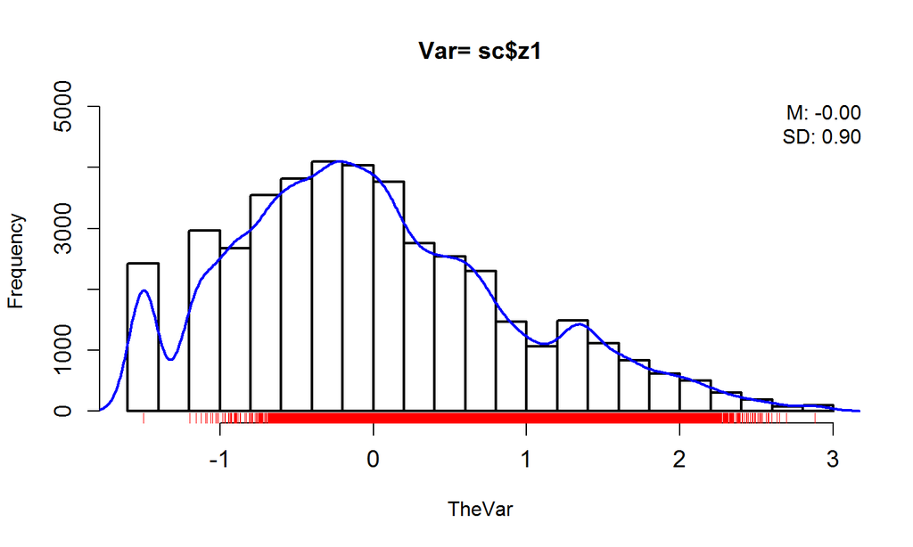

## Score from IRT model by SE

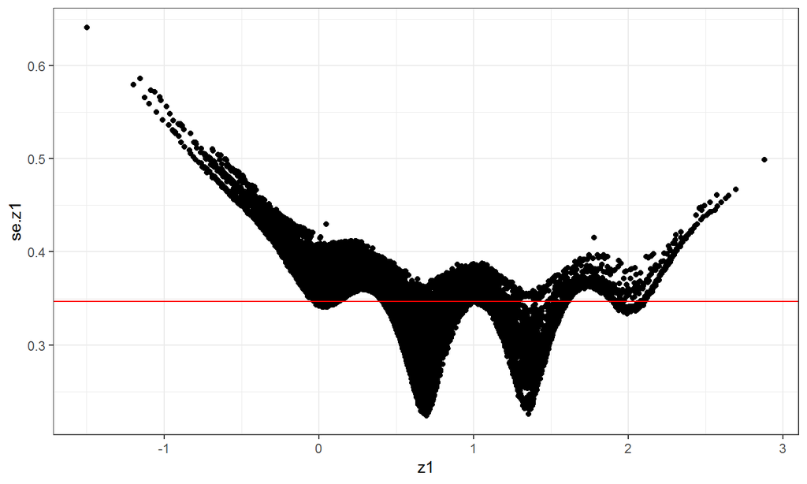

## Information Function

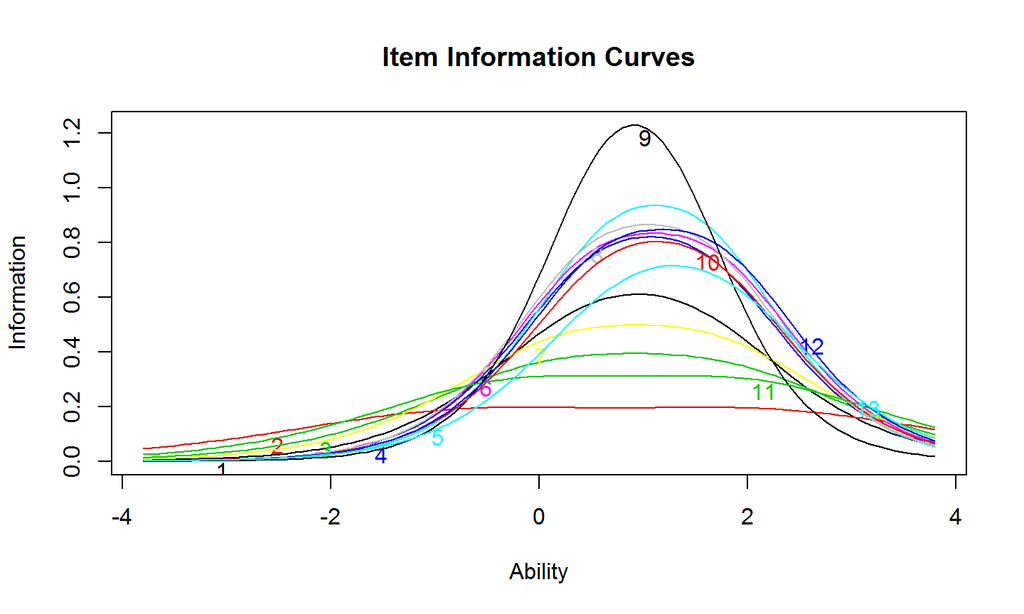

## Test Information Curve

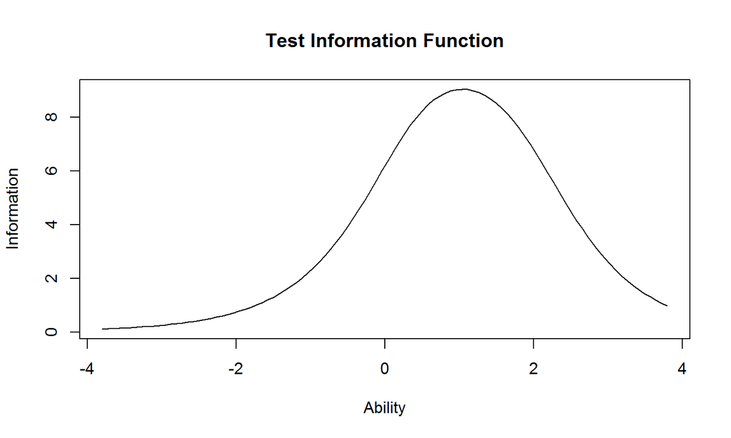

## Differential Item Functioning

```r
m1<-glm(I(lla1d > 1)~ z1,sc,family="binomial")
broom::tidy(m2<-glm(I(lla1d > 1)~ z1+intv,sc,family="binomial"))
```

```
## # A tibble: 5 x 5
##   term        estimate std.error statistic   p.value
##   <chr>          <dbl>     <dbl>     <dbl>     <dbl>
## 1 (Intercept)  -0.821     0.0249    -33.0  1.60e-238
## 2 z1            2.07      0.0208     99.4  0.
## 3 intvS        -0.0861    0.0353     -2.44 1.48e-  2
## 4 intvT         0.141     0.0357      3.96 7.38e-  5
## 5 intvX         0.348     0.0367      9.48 2.53e- 21
```

```r
anova(m1,m2,test="LRT")
```

```
## Analysis of Deviance Table
##
## Model 1: I(lla1d > 1) ~ z1
## Model 2: I(lla1d > 1) ~ z1 + intv
##   Resid. Df Resid. Dev Df Deviance Pr(>Chi)
## 1     42618      38007
## 2     42615      37852  3      155   <2e-16 ***
## ---
## Signif. codes:  0 '***' 0.001 '**' 0.01 '*' 0.05 '.' 0.1 ' ' 1
```